# Analyse de données agroalimentaire

### 6. Graphe des modalités de variables

Poussons à présent notre analyse en essayant de savoir les grandes tendances en représentant uniquement les modalités de variable.

#### i. Analyse sur l’axe 1 et 2

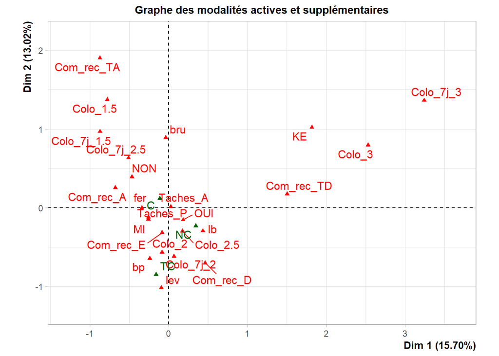

```r
plot(res.mca,invisible = "ind",title = "Graphe des modalités actives et supplémentaires")
```

En se basant sur les règles générales d’interprétation de proximité entre modalités de deux variables différentes ou non . Nous pouvons classer les fruits en fonction de la conformité à 7jours :

- Les fruits avec comme caractéristiques : de la levure au 7éme jour`lev`, `bp` beau produit ont tendance à être très conformes `TC`
- Les fruits fermentés au 7ème jour en l’absence de taches sont classés conformes `C`
- Enfin les fruits caractérisés par une présence de levures et de brunissement et avec des taches ont tendance à ne pas être conformes `NC`

#### ii. 8. Analyse sur l’axe 2 et 3

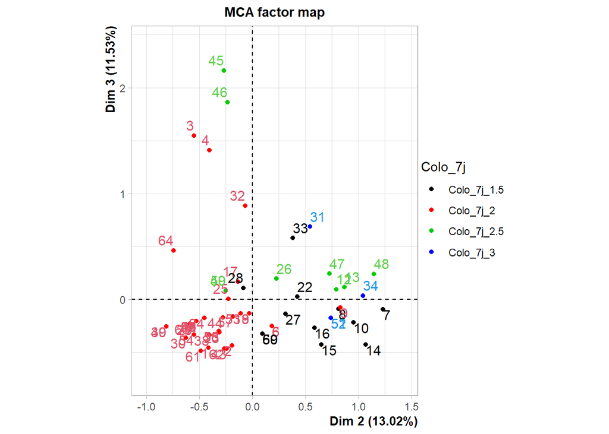

```r
options(ggrepel.max.overlaps = Inf)
plot(res.mca,invisible = c("var","quali.sup"),axes=2:3,habillage=5)
```

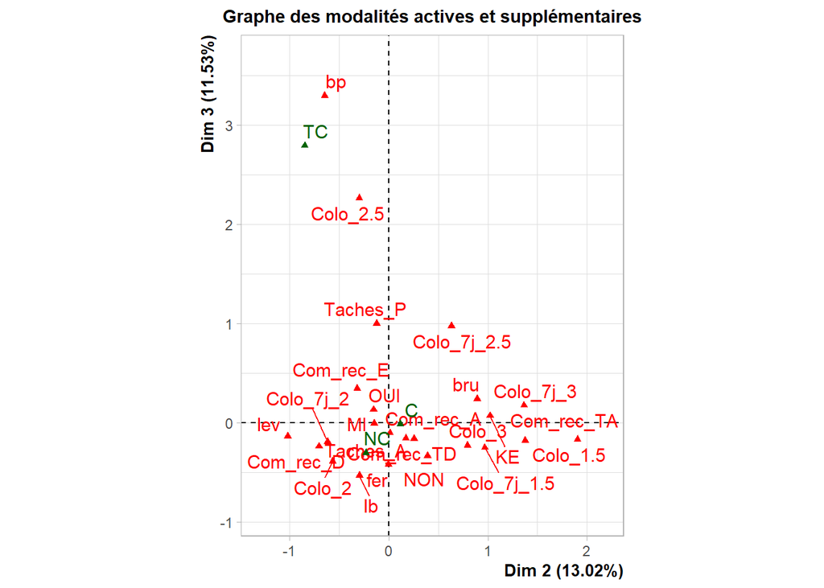

```r
plot(res.mca,invisible = "ind",axes=2:3,title = "Graphe des modalités actives et supplémentaires")
```

Ce graphe nous permet d’ajouter à l’ancienne typologie de fruits que :

Les fruits classés “Conformes” ont tendance à être aussi homogènes.

#### iii. Description automatique des axes

Les axes fournis par l’ACM peuvent être décrits de façon automatique par l’ensemble des variables, qu’elles soient quantitatives ou qualitatives, actives ou supplémentaires. Pour cela, nous utiliserons la commande `dimdesc` qui nous permettra de voir à quelles variables les axes sont le plus liés, quelles variables continues sont les plus corrélées à chaque axe et quelles variables qualitatives et quelles modalités le mieux chaque axe.

```r
dimdesc(res.mca)$'Dim 1'
```

```
## $quanti
##              correlation    p.value
## Productivite   0.2729246 0.02911165
##
## $quali
##                      R2      p.value
## Colo_7j      0.84159179 5.669939e-24
## Colo         0.64002162 2.464128e-13
## Fournisseurs 0.47164153 3.721100e-10
## Com_rec      0.53680977 2.323475e-09
## Homo_7j      0.08488725 1.950068e-02
##
## $category
##                       Estimate      p.value
## Colo_7j=Colo_7j_3    1.7031288 7.445301e-18
## Colo=Colo_3          1.2772982 4.168380e-12
## Fournisseurs=KE      0.6411025 3.721100e-10
## Com_rec=Com_rec_TD   0.8863764 1.004562e-07
## Homo_7j=OUI          0.2000629 1.950068e-02
## Carac_7j=lb          0.3024120 2.975303e-02
## Homo_7j=NON         -0.2000629 1.950068e-02
## Colo=Colo_1.5       -0.7644964 7.264360e-04
## Colo_7j=Colo_7j_1.5 -0.8349326 5.875329e-04
## Com_rec=Com_rec_A   -0.4589656 2.796703e-04
## Fournisseurs=MI     -0.6411025 3.721100e-10
##
## attr(,"class")
## [1] "condes" "list"
```

```r
dimdesc(res.mca)$'Dim 2'
```

```
## $quali
##                     R2      p.value
## Colo         0.6582347 5.260275e-14
## Colo_7j      0.5796712 2.458355e-11
## Carac_7j     0.4033649 3.118703e-06
## Com_rec      0.3612979 2.103468e-05
## Fournisseurs 0.1490601 1.627515e-03
##
## $category
##                        Estimate      p.value
## Colo=Colo_1.5        0.58955503 9.314850e-12
## Carac_7j=bru         0.62116014 1.712618e-06
## Com_rec=Com_rec_TA   0.92255972 3.756641e-05
## Colo_7j=Colo_7j_1.5  0.21404899 1.084405e-04
## Fournisseurs=KE      0.32821817 1.627515e-03
## Colo_7j=Colo_7j_3    0.43666949 4.323271e-03
## Colo_7j=Colo_7j_2.5  0.02575112 2.942703e-02
## Com_rec=Com_rec_D   -0.54269678 1.509055e-02
## Carac_7j=lev        -0.45272195 1.680956e-03
## Fournisseurs=MI     -0.32821817 1.627515e-03
## Colo=Colo_2         -0.50112011 2.997606e-09
## Colo_7j=Colo_7j_2   -0.67646960 1.775893e-12
##
## attr(,"class")
## [1] "condes" "list"
```

```r
dimdesc(res.mca)$'Dim 3'
```

```
## $quali
##                 R2      p.value
## Carac_7j 0.8234337 1.537288e-21
## Colo     0.7409420 1.366527e-17
## Conf_7j  0.2673107 7.586729e-05
## Colo_7j  0.1850391 6.197905e-03
## Taches   0.1034181 9.563729e-03
##
## $category
##                       Estimate      p.value
## Colo=Colo_2.5        1.0049468 1.928644e-19
## Carac_7j=bp          1.4867198 4.961546e-19
## Conf_7j=TC           1.0420848 2.400444e-05
## Colo_7j=Colo_7j_2.5  0.4231528 5.577736e-04
## Taches=Taches_P      0.2919185 9.563729e-03
## Com_rec=Com_rec_E    0.2225342 4.741068e-02
## Taches=Taches_A     -0.2919185 9.563729e-03
## Carac_7j=lb         -0.5411335 6.919256e-03
## Colo=Colo_2         -0.4006199 1.444664e-04
##
## attr(,"class")
## [1] "condes" "list"
```

La description des axes obtenue à partir des données qualitatives confirme la description faite des axes.

La commande dimdesc nous permet de mesurer la significativité de la représentation des variables sur les axes :s’il s’agit des variables qualitatives nous nous baserons sur la colonne “R2” puis s’il s’agit des variables quantitatives ,sur la colonne “corrélation”.

Nous voyons que la variable quantitative supplémentaire `Productivité` est corrélée positivement avec l’axe 1 à 28%. Malgré cette faible corrélation, nous pouvons déduire que : les fruits à coloration de niveau 3 (à la réception et à 7jours) ont tendance à augmenter la productivité puis les fruits acides à la réception, non homogènes et à coloration de niveau 1.5 ont tendance à la réduire.

Notons que la plupart des fruits qui ont tendance à augmenter la productivité ont été fournis par KE.

#### iv. Conclusion

Le bilan des liaisons entre les variables qualitatives met en évidence des corrélations positives entre les variables `Colo_7j`, `Colo`, `Homo_7j` , `Com_rec` et elles sont liées à la productivité même si c’est faible. Plus finement, ça voudrait dire que les fruits à coloration 3, homogènes et doux ont tendance à augmenter la productivité. Ensuite, on pourrait proposer une typologie des fruits en fonction de leur conformité, paramètre qui influence notamment sur la productivité.

- Les fruits à coloration 2.5/3, jugés “beau produit” sont classés “très conformes”.
- Les fruits qui n’ont pas de taches et fermentés au 7éme jour sont classés “conformes”
- Enfin, les fruits caractérisés par un brunissement de la chair comportant de la levure au jour 7, avec une présence de taches sont classés “non conformes”.

## VIII. Contruction de Modèle de prédiction

Dans cette section nous allons essayer de construire des modèles statistiques afin de prédire la productivité, le rendement et la conformité au jour 7.

Dans premier temps nous ferons une représentation du nuage de point entre chaque couple de variable quantitative.

### 1. Choix des variables du modèle

Pour la construction de nos modèles de régression et de classification nous retiendrons les variables suivantes : `Acidite`, `Brix`, `Tache`, `Hauteur`, `Diametre`, `Colo`, `Age_recep`

Dans un premier temps nous avons exclu les variables qui ont été mesurées après le phénomène que nous cherchons à expliquer car ces deux mesures sont éloignées dans le temps. Nous pouvons cité par exemple les variables dont les valeurs et modalités ont été déterminées au jour 7 et 8 (`Age_7j`, `Note_7j`, `Conf_7j`, `Colo_7j`, `Homo_7j`, `Carac_7j`,`Age_8j`, `Note_8j`, `Conf_8j`, `Colo_8j`, `Homo_8j` et `Carac_8j`)

Dans un deuxième temps nous avons utilisé les liaisons entre les variables pour déterminer les autres variables explicatives à retenir. Deux variables liées ont tendance à apporter les mêmes informations et peux entraîner des problèmes de multi-colinéarité par exemple. Ainsi lorsque deux variables sont liées on garde l’une des deux.

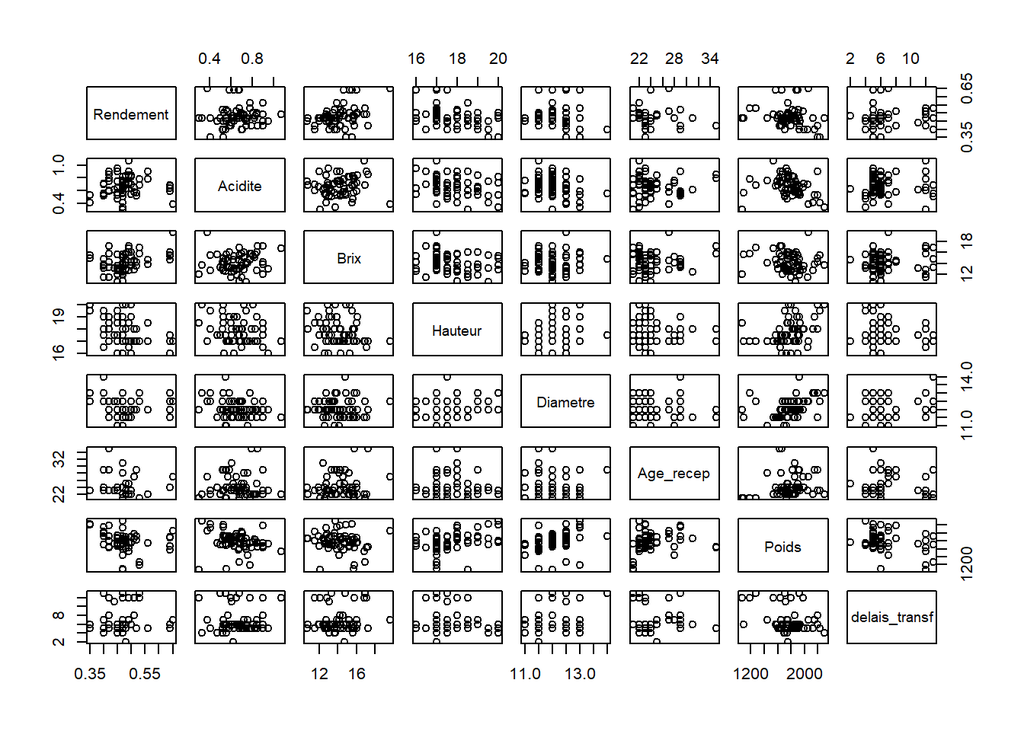

```r
regdatarp<-select(mydata2021,c(Rendement,Acidite, Brix,Hauteur, Diametre,Age_recep, Poids,delais_transf, Productivite,Taches, Colo))
plot(regdatarp[1:8])
```

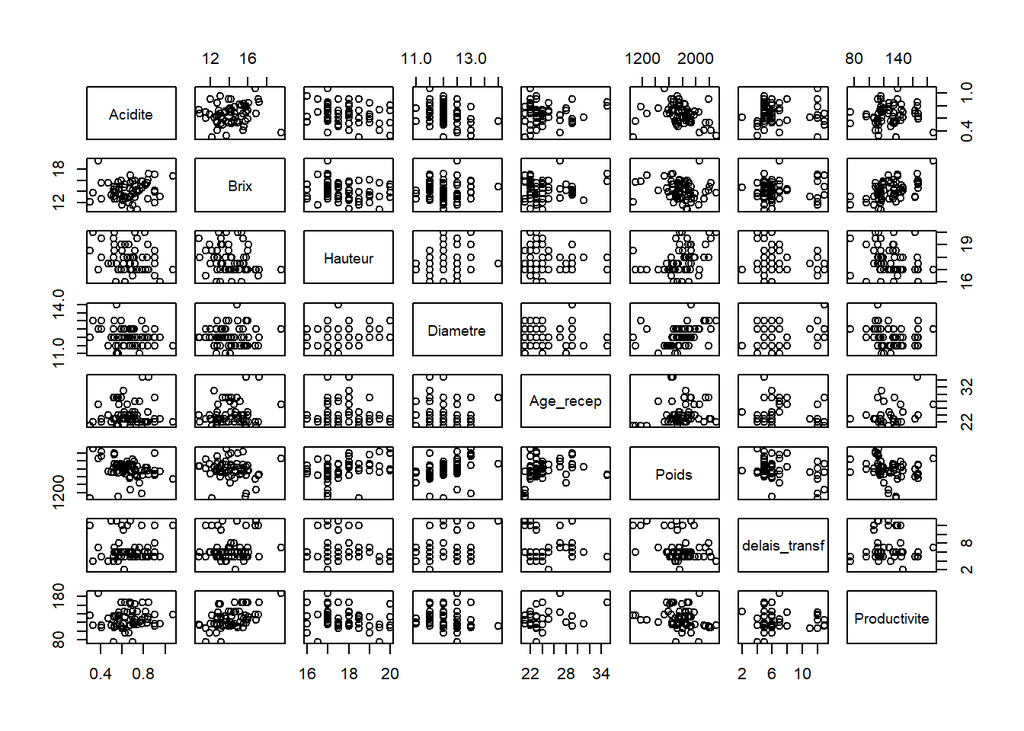

```r
plot(regdatarp[2:9])
```

Nous pouvons remarquer une absence de l’existence de lien linéaire entre Rendement et les autres variables il en est de même pour pour `Productivite`.

De ce fait l’utilisation de modèle linéaire n’est pas pertinente. Nous utiliserons les arbres de régression pour la construction des modèles permettant de prédire la productivité et le rendement car pour la construction des arbres de régression on accorde peu d’importance à la structure liant les variables explicatives aux variables expliquées, il n’y a pas d’hypothèse sous-jacente sur les variables et sur le modèle et les dépendances entre les variables explicatives ne posent pas de problème.

Afin de minimiser le taux d’erreur global et d’avoir un traitement efficace nous utiliserons des forêts d’arbres de régression qui est un ensemble d’arbre de régression. La valeur prédite sachant les variables expliquées pour un fruit est données par la moyenne des valeurs prédite des arbres de notre forêt.

Pour évaluer la qualité de notre modèle nous avons séparé notre jeux de données en deux bases que sont train et test. Le train sera utilisé pour la construction de notre modèle et test pour évaluer la qualité du modèle.

### 2. Creation du jeu de données Train et test

Train : Est le jeu de données sur lequel on va entraîner le modèle et qui correspond à 70% de nos données.

Test : Correspond à 30% de nos données. Nous allons l’utiliser pour tester le modèle créé sur le jeu de données train afin d’évaluer la performance de notre modèle.

```r
regdata<-select(mydata2021,c(Rendement,Brix,Acidite,Age_recep,Hauteur,Diametre,Poids,Colo,Taches,Com_rec,delais_transf,Productivite))
set.seed(123)
n = nrow(regdata)
s = sample(2, n, prob = c(0.7,0.3),replace = T)
#creation du train
train = regdata[s==1, ]
#creation du test
test = regdata[s==2, ]
```

#### i. Creation du modèle pour la prédiction du Rendement

On cherche à modéliser le rendement qui est une variable quantitative, on réalise donc une random forest de type régression.

```r
set.seed(123) # permet de fixer les paramètres aléatoires de la randf
#construction de la forêt aléatoire sur toute les variables
randf=randomForest(Rendement~Brix+Acidite+Age_recep+Hauteur+Diametre+Poids+Colo+Taches+Com_rec+delais_transf,importance = T, ntree = 500,data = train)
randf
```

```
##
## Call:
##  randomForest(formula = Rendement ~ Brix + Acidite + Age_recep +      Hauteur + Diametre + Poids + Colo + Taches + Com_rec + delais_transf,      data = train, importance = T, ntree = 500)
##                Type of random forest: regression
##                      Number of trees: 500
## No. of variables tried at each split: 3
##
##           Mean of squared residuals: 0.003411018
##                     % Var explained: 28.18
```

On observe ici que la variance expliquée par le modèle créé est d’environs 28.18% et l’erreur résiduelle de 0.003 environs. cette variance expliquée est en dessous de 50%, notre modèle n’est pas pertinent.

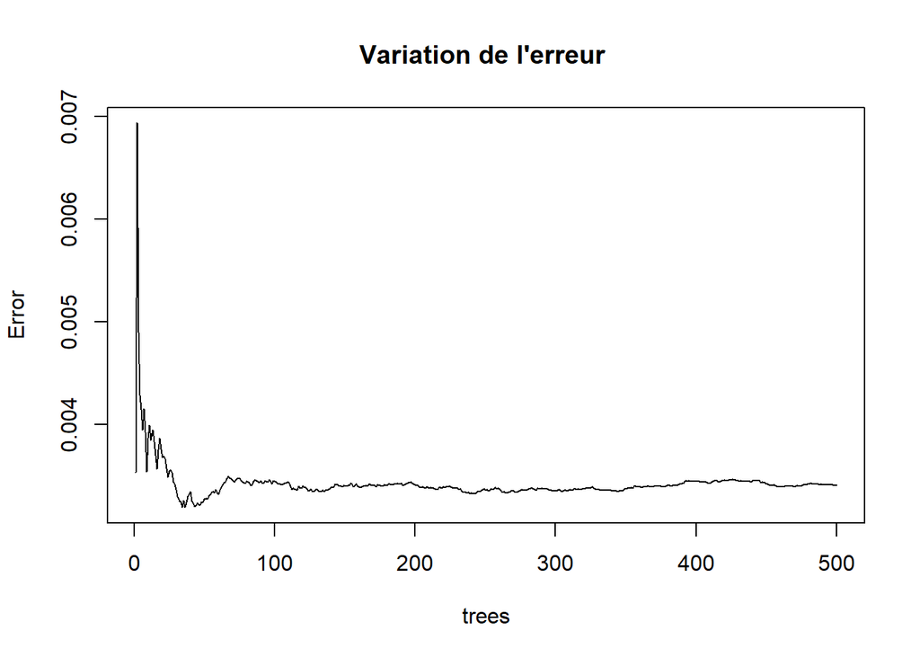

```r
plot(randf,main = "Variation de l'erreur ")
```

Le graphique ci-dessus nous indique l’évolution l’erreur en fonction du nombre d’arbre. On remarque qu’autour de 150 arbres l’erreur varie peu.

De ce fait, nous pouvons réduire le nombre d’arbre à 150 arbres pour gagner en temps de calcul et sans dégrader la qualité du modèle.

#### i. Classement des variables explicatives

Afin de visualiser les variables par ordre d’importance classées par le random forest, on utilise la commande `varImPlot`.

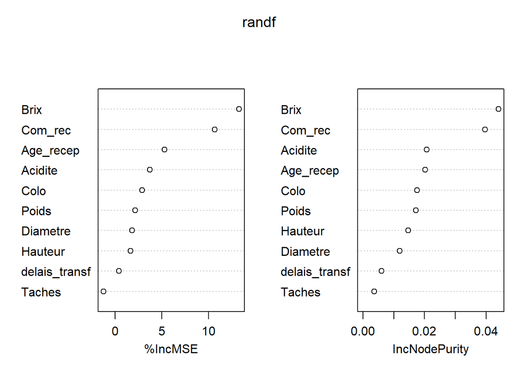

```r
varImpPlot(randf)
```

#### i. Validation du modèle

En appliquant notre modèle entrainè au jeu de données test nous pouvons voir les écarts entre la valeur prédite et la valeur réelle.

```r
pred <- predict(randf,test[2:12])
ecart_model1=round(abs(test$Rendement-pred),2)
results <- data.frame(actual = test$Rendement, prediction = round(pred,2), erreur=ecart_model1)
head(results)
```

```
##    actual prediction erreur
## 2    0.45       0.56   0.11
## 4    0.49       0.48   0.01
## 5    0.45       0.45   0.00
## 8    0.40       0.46   0.06
## 11   0.40       0.50   0.10
## 16   0.42       0.47   0.05
```

Pour la validation de notre modèle nous nous servirons de la racine carrée de l’erreur quadratique moyenne (RMSE). On pourra ainsi mesurer la capacité de notre modèle sur des données qui n’ont pas servi à son entrainement c’est à dire nos données de test.

```r
evaluation_model<-function(model){
  #prédiction sur le train
  train_predict<-predict(model,train[2:11])
  # calcul de l'erreur sur le train
  train_error<-train_predict-train$Rendement
    #prédiction sur le test
  test_predict<-predict(model,test[2:11])
  # calcul de l'erreur sur le test
  test_error<-test_predict-test$Rendement
  #RMSE sur le train
  rmse_train<-sqrt(mean(train_error**2))
  #RMSE sur le train
  rmse_test<-sqrt(mean(test_error**2))
  #affichage
  print(paste("rmse train",round(rmse_train,2)))
  print(paste("rmse test",round(rmse_test,2)))

    }
```

La fonction ci dessus permet obtenir le RMSE pour le train et le test. Les résultats du RMSE sur les données d’apprentissage est d’environ 0.03.

```r
 evaluation_model(randf)
```

```
## [1] "rmse train 0.03"
## [1] "rmse test 0.08"
```

### 3. Creation du modèle pour la prédiction de la productivité

Comme pour le rendement on cherche ici à modéliser la productivité qui est une variable quantitative, on réalise donc une random forest de type régression. On observe ici que la variance expliquée par le modèle créé est d’environs 29.93% et l’erreur résiduelle moyenne est de 415.97 environ.

```r
set.seed(123) # permet de fixer les paramètres aléatoires de la randf
randf2=randomForest(Productivite~Brix+Acidite+Age_recep+Hauteur+Diametre+Poids+Colo+Taches+Com_rec+delais_transf,importance = T, ntree = 500,data = train)
randf2
```

```
##
## Call:
##  randomForest(formula = Productivite ~ Brix + Acidite + Age_recep +      Hauteur + Diametre + Poids + Colo + Taches + Com_rec + delais_transf,      data = train, importance = T, ntree = 500)
##                Type of random forest: regression
##                      Number of trees: 500
## No. of variables tried at each split: 3
##
##           Mean of squared residuals: 415.9744
##                     % Var explained: 29.93
```

Le graphique ci dessous nous indique l’évolution de l’erreur en fonction du nombre d’arbres.

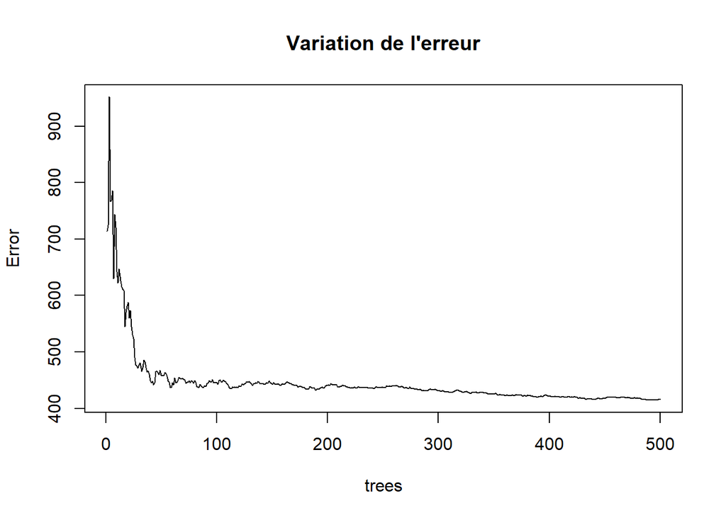

```r
plot(randf2,main = "Variation de l'erreur")
```

On remarque qu’autour de 100 arbres l’erreur varie peu. De ce fait, nous pouvons réduire le nombre d’arbre à 100 arbres pour gagner en temps de calcul et sans dégrader la qualité du modèle.

#### i. Importance des variables

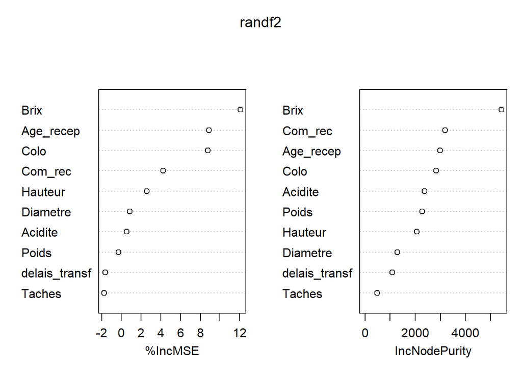

```r
varImpPlot(randf2)
```

#### i. Validation du modèle

En appliquant notre modèle entrainé au jeux de données test nous pouvons voir les écarts entre la valeur prédite et la valeur réelle de `Productivite`.

```r
pred2 <- predict(randf2,test[2:11])
ecart=round(abs(test$Productivite-pred2),2)
results <- data.frame(actual = test$Productivite, prediction = round(pred2,2), erreur=ecart)
head(results)
```

```
##    actual prediction erreur
## 2   129.6     144.20  14.60
## 4   127.6     136.91   9.31
## 5   116.5     114.74   1.76
## 8   115.7     126.10  10.40
## 11  111.8     132.28  20.48
## 16  111.7     128.17  16.47
```

```r
results <- data.frame(actual = test$Productivite, prediction = pred2)
head(results)
```

```
##    actual prediction
## 2   129.6   144.2046
## 4   127.6   136.9055
## 5   116.5   114.7389
## 8   115.7   126.0964
## 11  111.8   132.2786
## 16  111.7   128.1745
```

```r
evaluation_model(randf2)
```

```
## [1] "rmse train 133.24"
## [1] "rmse test 129.47"
```

En somme les modèles prédictifs pour le rendement et la productivité ne sont pas pertinent car les variances expliqué par nos modèles sont inférieurs à 50%.

### 3. Modèle de regression pour la Conformité à 7 jours

On s’intèresse à la conformité des fruits. L’évaluation de la conformité est classée selon trois modalités à savoir `C` pour `conforme`, `NC` pour `non-Conforme` et `TC` pour `très-Conforme`. Pour un fruit donnée on souhaite prédire la modalité de la conformité au septième jour en fonction des variables `Acidite`, `Brix`, `Tache`, `Hauteur`, `Diametre`, `Colo`, `Age_rec`. Avec trois modalités nous utiliserons un modèle de régression multinomiale.

```r
#création d'une base avec les variables pour la régression
datmul<-select(mydata2021,c(Conf_7j,Hauteur,Brix,Colo,Taches,Acidite,Diametre,Age_recep))
#creation du train et test pour la regression 70% train & 30% test
set.seed(123)
n = nrow(datmul)
s = sample(2, n, prob = c(0.7,0.3),replace = T)
#creation du train
trainreg = datmul[s==1, ]
#creation du test
testreg = datmul[s==2, ]
#modèle
regmul = multinom(Conf_7j~Hauteur+Brix+Colo+Taches+Acidite+Diametre+Age_recep,data = trainreg)
```

On affiche le résumé des estimations des coefficients de régression en faisant:

```r
summary(regmul)
```

```
## Call:
## multinom(formula = Conf_7j ~ Hauteur + Brix + Colo + Taches +
##     Acidite + Diametre + Age_recep, data = trainreg)
##
## Coefficients:
##    (Intercept)   Hauteur      Brix   Colo1.5    Colo2     Colo2.5      Colo3
## NC   1.3137905 -1.213246 0.5897114 -1.428036 1.490869  0.02937191   1.221585
## TC  -0.2173783  7.767987 2.4007516 -6.679206 2.352533 32.19953986 -28.090245
##       TachesP    Acidite   Diametre   Age_recep
## NC -0.8022394 -0.8045364  0.9875452 -0.06704456
## TC  0.8272768 -9.0526498 -8.7221997 -3.87684181
##
## Std. Errors:
##    (Intercept)    Hauteur       Brix      Colo1.5     Colo2   Colo2.5
## NC  13.2823955  0.6264232  0.4024747 3.557060e+00  3.094496  3.520088
## TC   0.4897549 44.0522815 26.7870075 2.949498e-08 15.795680 15.314882
##           Colo3    TachesP  Acidite   Diametre  Age_recep
## NC 4.879295e+00 1.76052192 4.266841  0.9341038  0.1535582
## TC 1.403296e-09 0.03329603 3.080415 19.9561628 26.6711312
##
## Residual Deviance: 36.47247
## AIC: 76.47247
```

#### i. Significativité du modèle

Pour mesurer l’influence des coefficients sur notre variable expliquée nous avons effectué le test de Wald. Le test de Wald est un test de significativité individuelle des coefficients. Il est basé sur les hypothèses suivantes:

H0: Il n’y a pas de variables influentes

H1: Au moins une variable des variables est influente

```r
 z= summary(regmul)$coeff / summary(regmul)$standard.errors
pvaleur = 2 * (1 - pnorm(abs(z), 0, 1))
pvaleur
```

```
##    (Intercept)    Hauteur      Brix   Colo1.5     Colo2   Colo2.5     Colo3
## NC   0.9212080 0.05277176 0.1428627 0.6880776 0.6299616 0.9933425 0.8023082
## TC   0.6571502 0.86003027 0.9285862 0.0000000 0.8816047 0.0355095 0.0000000
##      TachesP     Acidite  Diametre Age_recep
## NC 0.6486181 0.850441194 0.2904151 0.6623964
## TC 0.0000000 0.003295116 0.6620621 0.8844288
```

A partir des résultats du test de significativité des coefficients On remarque que :

On peut aussi faire le test du rapport de vraisemblance (lr) pour évaluer la significativité globale des coefficients de notre modèle.

```r
reg0 = multinom(Conf_7j~ 1,data = trainreg)
rv = reg0$deviance - regmul$deviance
ddl = regmul$edf - reg0$edf
pvaleur = 1 - pchisq(rv, ddl)
pvaleur
```

```
## [1] 0.04884883
```

Cela renvoie une p-valeur=0.0488 Ainsi, la régression multinomiale est significative avec la p-valeur est inférieure à 0.05.

#### ii. Taux d’erreurs

La matrice de confusion est une synthèse des résultats des classes prédite par notre modèle. Elle compare les données réelles de la conformité au jour 7 à celles prédites par un modèle. Le nombres de bonne prédiction pour chaque groupe de fruits est sur la diagonale. les autres valeurs sont des erreurs de prédictions pour chaque modèle.

```r
#matrice confusion
#2:8 c'est les variables du test.. le 1 c'est l'étiquette
pr = predict(regmul,testreg[,2:8])
mc = table(testreg$Conf_7j, pr)
mc
```

```
##     pr
##       C NC TC
##   C  10  3  2
##   NC  0  2  0
##   TC  1  0  0
```

Pour évaluer la qualité prédictive de notre modèle nous interpréterons le taux d’erreur. Ce taux est la proportion des modalités prédites qui diffèrent des modalités observées.

```r
t=(sum(mc)-sum(diag(mc)))/sum(mc)
t
```

```
## [1] 0.3333333
```

On obtient un taux d’erreur de 0.33 cela est inférieur à 0.5, de ce fait notre modèle à une bonne qualité prédictive.

Nous pouvons essayer d’améliorer ou de simplifier notre modèle en effectuant une sélection de variables. En effet en observant les résultats du test de wald, on peut remarquer que certains coefficients sont non significatifs. Mais l’approche qui consiste à éliminer d’un seul coup les variables non significatives n’est pas bonne ; certaines variables peuvent être corrélées à d’autres, ce qui peut masquer leur réelle influence sur la conformité au septième jour .

Ainsi en effectuant une sélection de variables par la méthode “stepwise” en utilisant comme critère de performance le AIC.

```r
reg1= step(regmul, direction = "both", k = 2)
```

```
## Start:  AIC=76.47
## Conf_7j ~ Hauteur + Brix + Colo + Taches + Acidite + Diametre +
##     Age_recep
##
## trying - Hauteur
## trying - Brix
## trying - Colo
## trying - Taches
## trying - Acidite
## trying - Diametre
## trying - Age_recep
##             Df      AIC
## - Colo      14 68.71601
## - Acidite   18 72.50816
## - Age_recep 18 72.66788
## - Taches    18 72.68575
## - Diametre  18 73.67113
## - Brix      18 75.15353
## <none>      20 76.47247
## - Hauteur   18 77.25248
##
## Step:  AIC=68.72
## Conf_7j ~ Hauteur + Brix + Taches + Acidite + Diametre + Age_recep
##
## trying - Hauteur
## trying - Brix
## trying - Taches
## trying - Acidite
## trying - Diametre
## trying - Age_recep
## trying + Colo
##             Df      AIC
## - Taches    12 64.78392
## - Age_recep 12 65.31220
## - Acidite   12 67.73070
## <none>      14 68.71601
## - Diametre  12 70.69961
## - Hauteur   12 74.96842
## - Brix      12 75.67757
## + +Colo     20 76.47247
```

[output cut: 45 more lines]

```
## trying - Brix
## trying - Diametre
## trying + Colo
## trying + Taches
## trying + Acidite
## trying + Age_recep
##              Df      AIC
## <none>        8 60.24377
## + +Acidite   10 61.33168
## - Diametre    6 63.82767
## + +Taches    10 63.92142
## + +Age_recep 10 63.98729
## + +Colo      14 65.15771
## - Brix        6 66.55958
## - Hauteur     6 66.61947
```

```r
summary(reg1)
```

```
## Call:
## multinom(formula = Conf_7j ~ Hauteur + Brix + Diametre, data = trainreg)
##
## Coefficients:
##     (Intercept)    Hauteur       Brix    Diametre
## NC -0.189058718 -0.7856596  0.4310384   0.5682312
## TC  0.003793494 22.3228124 23.6167827 -68.1202976
##
## Std. Errors:
##    (Intercept)    Hauteur     Brix  Diametre
## NC  11.4164848  0.4628562  0.23700 0.7150534
## TC   0.1452023 20.3485802 21.07079 2.3351075
##
## Residual Deviance: 44.24377
## AIC: 60.24377
```

Après la sélection des variables les variables qui ont été retenue pour la prédiction de la conformité sont: `Hauteur`, `Brix`, et `Diamètre`. notre nouveau modèle obtenu à un AIC de 60.24377.

#### iii. Etude de la significativté du deuxième modèle

Le test de Wald pour de la significativité des variables explicatives donne:

```r
 z= summary(reg1)$coeff / summary(reg1)$standard.errors
pvaleur = 2 * (1 - pnorm(abs(z), 0, 1))
pvaleur
```

```
##    (Intercept)    Hauteur       Brix  Diametre
## NC   0.9867875 0.08961802 0.06895308 0.4268057
## TC   0.9791572 0.27263237 0.26236011 0.0000000
```

Pour la classe de la non-conformité (NC) il n’y a pas de coefficient significativement différent de 0 au seuil de 5%

Pour la classe très Conforme(TC), seul le diamètre est hautement significatif.

Le test de significativité globale du deuxième modele donne :

```r
reg0 = multinom(Conf_7j~ 1,data = trainreg)
rv = reg0$deviance - reg1$deviance
ddl = reg1$edf - reg0$edf
pvaleur = 1 - pchisq(rv, ddl)
pvaleur
```

```
## [1] 0.001695524
```

Après le test de significativité globale on obtient une p-valeur = 0.0016 nous conclure que notre deuxième régression est très significative.

#### iv. Taux d’erreur

```r
pr = predict(reg1,testreg[,2:8])
#matrice confusion
mc = table(testreg$Conf_7j, pr)
mc
```

```
##     pr
##       C NC TC
##   C  13  2  0
##   NC  2  0  0
##   TC  1  0  0
```

```r
t1=(sum(mc)-sum(diag(mc)))/sum(mc)
t1
```

```
## [1] 0.2777778
```

On obtient un taux d’erreur de 0.277 cela est inférieur à 0.5, de ce fait notre modèle a une bonne qualité prédictive.

```r
a=paste("AIC modèle 1 : ",round(AIC(regmul),2))
b=paste("AIC modèle 2 : ",round(AIC(reg1),2))
d=paste("Taux d'erreur modèle 1 : ", round(t,3))
e=paste("Taux d'erreur modèle 2 : ", round(t1,3))
rbind(a,b,d,e)
```

```
##   [,1]
## a "AIC modèle 1 :  76.47"
## b "AIC modèle 2 :  60.24"
## d "Taux d'erreur modèle 1 :  0.333"
## e "Taux d'erreur modèle 2 :  0.278"
```

Une analyse comparative de nos deux modèles indique que le deuxième modèle a le plus petit taux d’erreur. de plus son AIC est le plus petit. Pour de futures prédictions, il est préférable d’utiliser le deuxième qui est plus simple (moins de variables) et plus performant que le modèle initial en termes de AIC et du taux d’erreur.

## IV. Conclusion et Discussion

L’agro-alimentaire est un secteur dynamique. Les différents acteurs cherchent de nouvelles informations pour améliorer la qualité de leurs produits et de maximiser leurs profits. A travers cette étude nous voulons fournir quelques outils d’aides à la décision pour une entreprise agro-alimentaire sur la découpe de fruit. Deux séries de données sur l’année 2020 et 2021 ont été mises à notre disposition.

Pour y arriver, nous nous sommes d’abord penchés sur une analyse comparative annuelle de certaines données. Nous y avons utiliséss des approches graphiques puis des approches numérique à travers les tests statistiques.

Par la suite nous avons mis en évidence les éventuelles liaisons entre variables. Il a aussi été le lieux d’expliquer la variabilité des données à travers de nouvelles variables synthétiques et de détecter les variables explicatives qui ont servit à la construction de nos modèles de régression et de classification.

Nous allons à présent discuter sur quelques résultats obtenus au cours de notre étude.

Le critère d’évaluation de certaines variables ont changé d’une année à l’autre cela nous a conduit à faire du recodage afin d’avoir les mêmes modalités qui nous ont permis de faire une comparaison par année. Cela peut masquer l’effet réelle d’une ou de plusieurs modalités.

La présence de valeurs manquantes en 2020 nous conduit à considérer uniquement les données de l’année 2021 pour la suite de nos analyses, ainsi les éventuelles liaisons de variables et typologies de fruits en 2020 n’ont pas été prises en compte dans notre étude.

Pour la construction des modèles régressions pour le `Rendement` et `Productivité` les variances expliquées sont inférieures à 50%, ces deux modèles ne sont pas satisfaisants car ils n’expliquent pas les variabilités présentes dans nos données. Cela pourrait être lié à la taille des données qui ont été utilisées pour entraîner nos modèles.

## V. Bliographie

François Husson, Sébastien Lê, Jérôme Pagès, Analyse des données avec R, 2e édition revue et augmentée.

François Husson et Jérôme Pagès, Statistiques générales pour les utilisateurs, 2-Exercices et corrigés.

François Husson et al, R pour la statistique et la science des données.

Christophe Chesneau, Introduction aux arbres de decision https://chesneau.users.lmno.cnrs.fr/arbres.pdf

Christophe Chesneau, Modèles de régression https://chesneau.users.lmno.cnrs.fr/Reg-M2.pdf

Christophe Chesneau, Element de classification https://chesneau.users.lmno.cnrs.fr/classif-cours.pdf